# Text Prediction: Milestone Report

Rona Stewart

2024-03-29

## Introduction

The purpose of this report is to provide an initial view of the data available to support the Capstone project for the Johns Hopkins University Data Science Specialisation. This project involves the creation and publication of a predictive text product which will take an input of a phrase (multiple words) in a text box and output a prediction of the next word.

Essentially, this means we are looking for a dataset containing strings of text which can be assessed for specific patterns and frequencies of word counts, for example how often specific word combinations appear, in order to train an algorithm to identify suggestions for the next word, given a series of predictor words.

This early report will set out an overview of the data and some characteristics, as well as detailing the intended next steps in developing an algorithm for the prediction model.

## Obtaining and Reading the Data

The data are provided by Johns Hopkins University in partnership with SwiftKey, and made available via the [Coursera website](https://d396qusza40orc.cloudfront.net/dsscapstone/dataset/Coursera-SwiftKey.zip) as at 2024-03-29.

The first stage is to download and read the data, which shows that there are four different languages of data provided (English, Finnish, German and Russian). For the purposes of this project, the English language dataset is utilised. Within the English language folder, there are three files, sourced from blogs, news articles and tweets. Given that the dataset will be used to train a language model, it is separated into a training set. Since there is a large volume of data available, 30% of each file is randomly selected to be included in the training set. This is summarised below:

```
# A tibble: 3 × 3
  Source_file Total_lines Sample_lines
  <chr>             <int>        <int>
1 Blogs            899288       269788
2 News              77259        23180
3 Twitter         2360148       708048
```

Taking the training datasets then, we consider the total and average number of words from each source, as well as the most frequent word (noting that common joining words, such as “the”, “a”, “in” etc. have been removed):

```
# A tibble: 3 × 6
  Sample  Total_lines Total_words Max_words Ave_words Most_freq_word
  <chr>         <int>       <int>     <int>     <dbl> <chr>
1 Blogs        269788    11181033      1379      41   one
2 News          23180      797678       363      34.4 said
3 Twitter      708048     9049053        58      12.8 just
```

## Visualising the Data

Finally, we consider the distribution of lengths (in words) of the lines from each source:

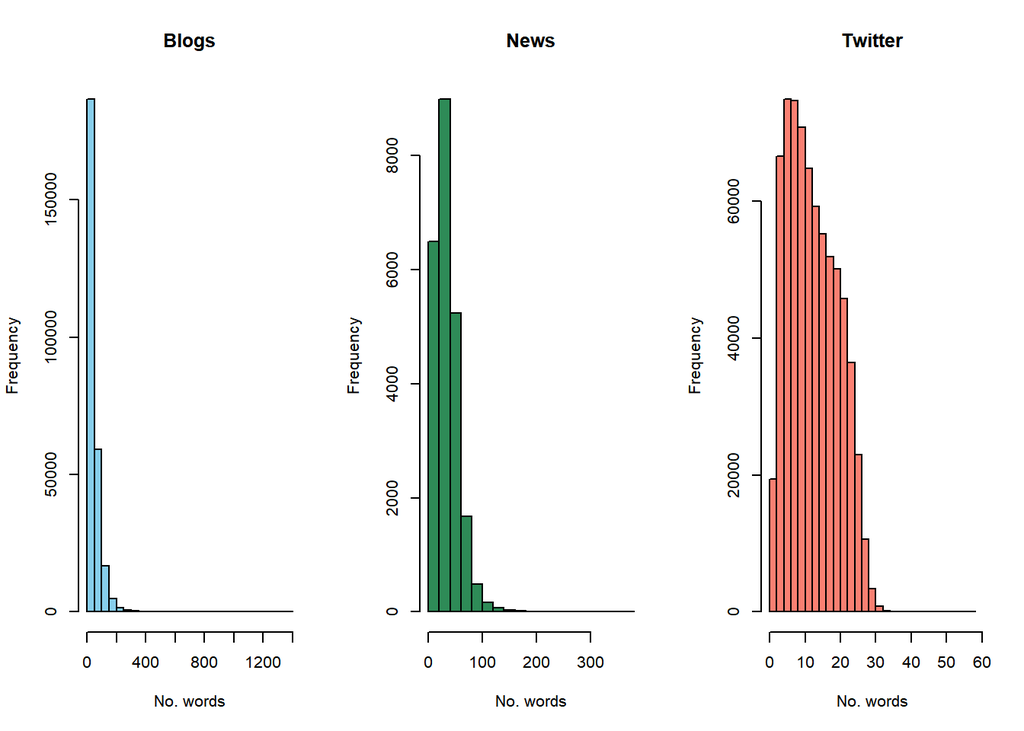

## Summary of Observations

Generally, it can be observed that while there is a fairly broad range (particularly from Blogs and News sources), the word count for the vast majority of the lines is skewed to the lower end of the range in each case.

## Next Steps

It is intended that the [Katz’s Back-off model](https://en.wikipedia.org/wiki/Katz%27s_back-off_model) will be used to develop the prediction algorithm. In order to use this, the the data will be considered as a series of unigrams, bigrams and trigrams (i.e. one word groupings, two-word groupings and three-word groupings), with frequencies attached to each. This will enable a probability of a specific word occurring given the previous word(s) - the input phrase in the app.

## Appendix 1: Environment

The environment this analyses was undertaken in is described below:  
* OS: Windows  
* CPU: intel COREi5  
* Software: RStudio 2023.12.1+402 “Ocean Storm” Release (4da58325ffcff29d157d9264087d4b1ab27f7204, 2024-01-28) for windows, Mozilla/5.0 (Windows NT 10.0; Win64; x64) AppleWebKit/537.36 (KHTML, like Gecko) RStudio/2023.12.1+402 Chrome/116.0.5845.190 Electron/26.2.4 Safari/537.36  
* R version 4.3.2 (2023-10-31 ucrt), Platform: x86_64-w64-mingw32/x64 (64-bit)  
* RStudio libraries: tidytext, tm, quanteda, dplyr, quanteda.textstats, data.table

## Appendix 2: Code

```r
knitr::opts_chunk$set(echo = FALSE, results = "hide", warning = FALSE, message = FALSE)

# Load the relevant libraries
library(tidytext); library(tm); library(quanteda); library(dplyr); library(quanteda.textstats); library(data.table)
```

```r
## Obtain the datasets
download.file ("https://d396qusza40orc.cloudfront.net/dsscapstone/dataset/Coursera-SwiftKey.zip","Coursera-SwiftKey.zip")

## Unzip the dataset
zipfilepath <- "./Coursera-Swiftkey.zip"
extracted_dir <- "./Data"
if (!dir.exists(extracted_dir)) {
        dir.create(extracted_dir)
}
unzip(zipfilepath, exdir = extracted_dir)
```

```r
# Create a directory path to the files
firstfolder <- list.files("./Data")
filepath <- file.path("./Data",firstfolder)

secondfolder <- list.files(file.path(".","Data",firstfolder))
allfilepaths <- NULL

for (i in 1:length(secondfolder)){
        thirdfolder <- list.files(file.path(".","Data",firstfolder,secondfolder[i]))
        allfilepaths <- c(allfilepaths, file.path(".","Data",firstfolder, secondfolder[i],thirdfolder))
}

# Explore the EN data files
ENfiles <- allfilepaths[4:6]
len1 <- length(readLines(ENfiles[1])) # Note that this returns 899288 entries
len2 <- length(readLines(ENfiles[2])) # Note that this returns 77259 entries
len3 <- length(readLines(ENfiles[3])) # Note that this returns 2360148 entries

# Given the volume of data, read only a random subset (30%) of each file in to the training data for manipulation
### Set seed to ensure reproducability of results
set.seed(1240)
### Create a vector identifying those elements for the training set
inTrain1 <- caret::createDataPartition(y = (1:len1), p=0.3, list = TRUE)
inTrain2 <- caret::createDataPartition(y = (1:len2), p=0.3, list = TRUE)
inTrain3 <- caret::createDataPartition(y = (1:len3), p=0.3, list = TRUE)

# Read in the data and create the subset for analysis
data1 <- readLines(ENfiles[1], skipNul = TRUE)
blogssub <- data1[inTrain1$Resample1]

data2 <- readLines(ENfiles[2], skipNul = TRUE)
newssub <- data2[inTrain2$Resample1]

data3 <- readLines(ENfiles[3], skipNul = TRUE)
twitsub <- data3[inTrain3$Resample1]

datasub <- c(blogssub, newssub, twitsub)
```

```r
sumLines <- tibble(Source_file = c("Blogs","News","Twitter"),
                   Total_lines = c(len1, len2, len3),
                   Sample_lines = c(length(blogssub), length(newssub),length(twitsub)))
sumLines
```

```r
# Manipulate the training datasets to tokens
blogssub <- tokens(blogssub, remove_punct = TRUE)
newssub <- tokens(newssub, remove_punct = TRUE)
twitsub <- tokens(twitsub, remove_punct = TRUE)

# Create tables of the most frequent word for each source
dfmat_blogs <- blogssub %>% tokens_remove(stopwords("english")) %>% dfm()
dfmat_news <- newssub %>% tokens_remove(stopwords("english")) %>% dfm()
dfmat_tweets <- twitsub %>% tokens_remove(stopwords("english")) %>% dfm()

# Create a table summarising the lines and words in each training dataset
sumSamples <- tibble(Sample = c("Blogs","News","Twitter"),
                     Total_lines = c(length(blogssub), length(newssub), length(twitsub)),
                     Total_words = c(sum(ntoken(blogssub)),sum(ntoken(newssub)),
                                     sum(ntoken(twitsub))),
                     Max_words = c(max(ntoken(blogssub)), max(ntoken(newssub)),
                                   max(ntoken(twitsub))),
                     Ave_words = c(round(mean(ntoken(blogssub)),0),
                                   round(mean(ntoken(newssub)),1),
                                   round(mean(ntoken(twitsub)),1)),
                     Most_freq_word = c(textstat_frequency(dfmat_blogs,n=1)[1,1],
                                        textstat_frequency(dfmat_news,n=1)[1,1],
                                        textstat_frequency(dfmat_tweets,n=1)[1,1]))
sumSamples
```

```r
# Create histograms of word count frequency
par(mfrow = c(1,3))
hist(ntoken(blogssub), col = "skyblue", main = "Blogs", xlab = "No. words");
hist(ntoken(newssub), col = "seagreen", main = "News", xlab = "No. words");
hist(ntoken(twitsub), col = "salmon", main = "Twitter", xlab = "No. words")
```

```r
# Create a single ranked data table of frequency of words across all sources
dfmat_all <- rbind(dfmat_blogs, dfmat_news, dfmat_tweets)
all_ranked <- textstat_frequency(dfmat_tweets)
all_ranked <- all_ranked %>%
        mutate(cumfreq = cumsum(frequency)) %>%
        mutate(prop = cumfreq/(sum(frequency)))
```